# Introduction to statistics

author: Alejandro Cáceres date:  
autosize: true

Barcelona East School of Engineering  
Universitat Politècnica de Catalunya (UPC)

Lecture 4

# Objective

Discrete probability models:

- Uniform and Bernoulli probability functions
- Binomial, geometric and negative binomial probability functions
- Hypergeometric probability function
- Poisson probability function

# Discrete probability models

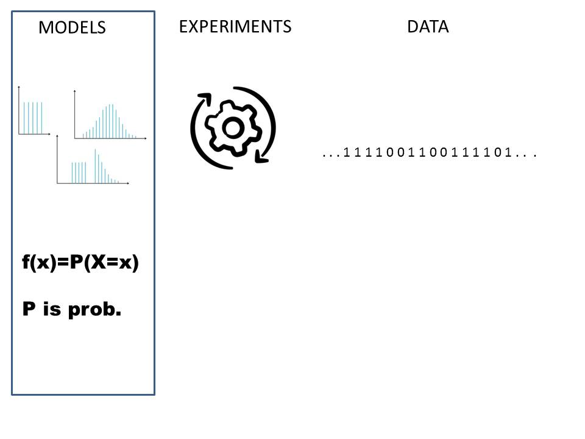

# Discrete probability models

A mass probability function of a discrete random variable X with possible values $x_1 , x_2 , .. , x_m$ is **any function** such that

- $f(x_i)\geq 0$
- $\sum_{i=1}^m f(x_i)=1$
- $f(x_i)=P(X=x_i)$

They are abstract objects with general properties that may or may not **describe** a natural or engineered process.

# Discrete probability models

Discrete probability models are probability mass functions that we **believe** describe processes like real random experiments.

Analogy: Think of the function $f(x,y)=x^2+y^2$

- $f(x,y)=a^2$ is a circle of radius $a$.
- it is an abstract object.
- it represents the shape of many real objects.
- the shape of real objects is an approximation of the circle.

# Discrete probability models

Discrete random models are functions that are **idealizations** of random experiments on discrete variables.

- What is the simplest model?

# Discrete probability models

The classical interpretation of probability (Laplace)

Whenever a sample space consists of N possible events that are equally likely, the probability of each outcome is $\frac{1}{N}$.

On many occasions:

- we can reason the possible values that a random variable can take.
- we have no reason to suppose that one outcome is more probable than the other.

# Uniform distribution

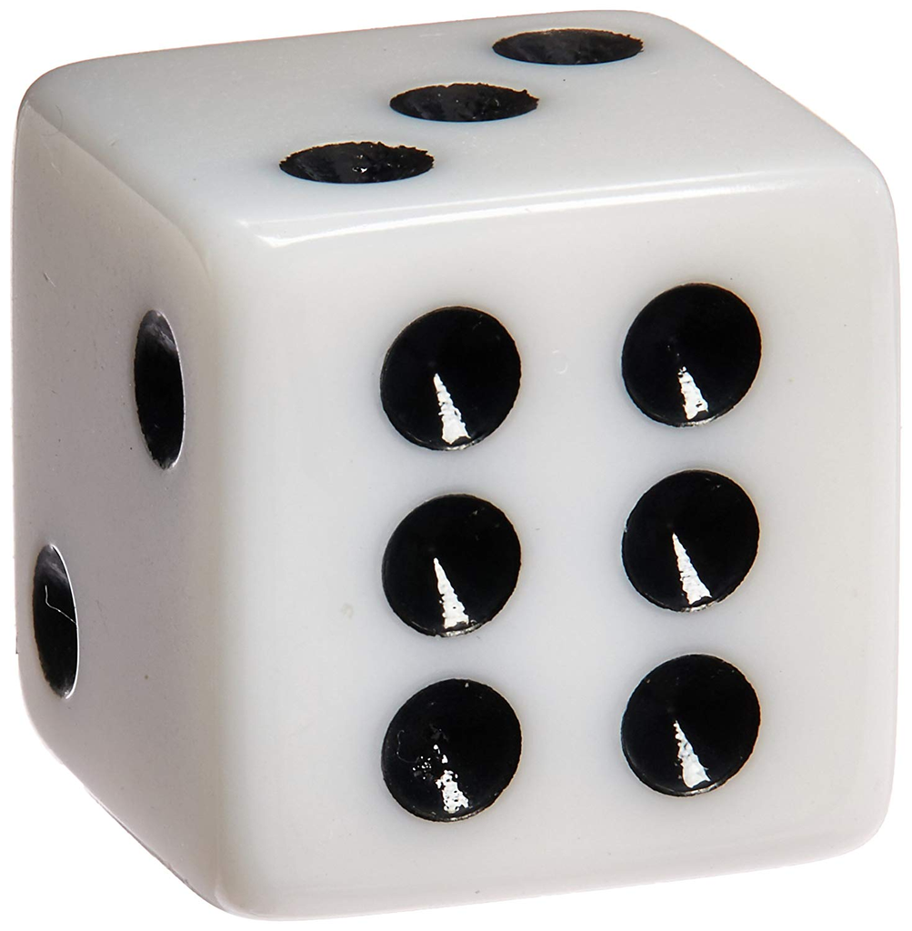

Think of a dice or the lottery:

- we can count all possible outcomes (dice:1-6, lottery:0000-9999)
- we have a strong belief that they all are equally probable (dice: $1/6$, lottery: $10^{-4}$) because the game is fair and before the game, we are completely ignorant of the outcome!

# Uniform distribution

**Definition** A random variable X has a discrete uniform distribution if each of the n values in its range, say, has equal probability. Then, $f(x)=\frac{1}{n}$

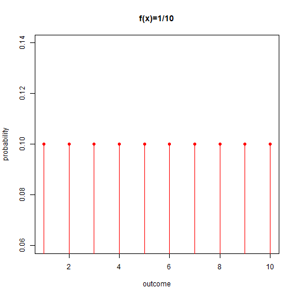

# Uniform distribution

- If $f(x)$ for $x\in\{a, a+1, ...b\}$, where $a$ and $b$ are integer, the size of the sample space is: $n=b-a+1$
- If all the the events are equally probable then
  $$f(x)=\frac{1}{b-a+1}$$

# Uniform distribution

Let’s compute the mean of the uniform distribution.

- changing variables for $Y=X-a+1$, $y\in\{1, 2, ...n\}$ then

$$f(y)=\frac{1}{n}$$
.

- and the fact that $\sum_{y=1}^n y = \frac{n(n+1)}{2}$

then the mean $E(Y)$, is given by

$E(Y)\sum_{y=1}^n y\big(\frac{1}{n}\big)=\frac{n+1}{2}$

and $E(X)=E(Y+a-1)=\frac{n+1}{2}+a-1=\frac{(b-a+1)+1}{2}+a-1=\frac{b+a}{2}$

# Uniform distribution

The variance of $Y$ is

$V(Y) = E(Y^2)-E(Y)^2$

$= \sum_{y=1}^n y^2\big(\frac{1}{n}\big) -E(Y)^2$

$= \frac{1}{n}\frac{n(n+1)(2n+1)}{6} -\big(\frac{n+1}{2}\big)^2$

$= \frac{n^2-1}{12}$

because $V(Y)=V(X)$ then $V(X)=\frac{(b-a+1)^2-1}{12}$

# Uniform distribution

What is the mean and variance of a dice?

Sample space $X\in\{1,2,3,4,5,6\}$ then $n=6$

- $E(X)=\frac{n+1}{2}=3.5$. Note that the expected value is not in the sample space! (is not a possible outcome)
- $V(X)=\frac{n^2-1}{12}=2.91$

# Bernoulli trials

The simplest case of a mass probability function is where there are **two possible** outcomes ($A$ and $B$). If they are equally probable we have the flip of a coin.

- let’s try to advance from the equal probability case and suppose that the outcomes have unequal probabilities

# Bernoulli trials

What if we let them have different probabilities

- outcome A (success): has probability $p$
- outcome B (failure): has probability $q=1-p$ ($q+p=1$)

Then we define the random variable $K$ (big $K$) where $k=1$ (little $k$) when the observation is $A$ and $k=1$ abd $k=0$ when the observation is $B$.

# Bernoulli trials

The probability mass function of $K$ is
$$P(K=k)=f(k)=
\begin{cases}
q=1-p,& \text{if } k=0\, (event\, B)\\
p,& k=1\, (event\, A)
\end{cases}$$

or more shortly

$f(k)=(1-p)^{1-k} p^k$, for $k=(0,1)$

# Bernoulli trials

Every time we have two different outcomes, where we can define a variable $k=0$ for one outcome and $k=1$ for the other.

We think of a Bernulli probability function $f(k)=(1-p)^{1-k} p^k$.

- In the uniform distribution, if we know the outcomes the mass probability distribution is fully known.
- In a Bernoulli trial we allow ourselves the flexibility of not knowing the number $p$ (the probability relationship between the outcomes).

# Bernoulli trials

$p$ is a **parameter** of the distribution: it is allowed to change.

- Bernoulli trial is really a **family** of distributions
- when we fix the value of $p$ then we have a single probability mass function $f(k;p)$.

Why do we let $p$ free? because our hope is that data, the real observations, will tell us what its value is (from lecture 7 on estimation onwards).

# Bernoulli trials

For the following lectures, we are going to assume we know the value of $p$.

- When we flip a coin then we “know” that $A$:Tail$\rightarrow k=1$ and $B$:Head $\rightarrow k=0$ have equall probabilities and therefore $p=1/2$ and

$$f(k)=\frac{1}{2}^{1-k} \frac{1}{2}^k= \frac{1}{2}$$
.

- If we **assume** that the probability of erroneously transmiting ($k=1$) one bit of information is $p=1/10$ then if the correct transmission of the bit is $k=0$, we have

$$f(k)=\frac{9}{10}^{1-k} \frac{1}{10}^k$$

# Bernoulli trials

What is the mean and variance of $f(k)=(1-p)^{1-k} p^k$?

- The mean $E(K)= \sum_{k=0}^1 k f(k)=f(1)=p$
- The variance $V(K)= \sum_{k=0}^1 (k-p)^2 f(k)$

$= p^2(1-p)+(1-p)^2p$

$= (1-p)(p^2 + p-p^2)$

$= (1-p)p = pq$

# Binomial distribution

Suppose that we are interested in learning about a particular Bernoulli trial.

- We repat the Bernoulli trial $n$ times and count how many times we obtained $A$.
- We define a random variable $X$ such that it counts in $n$ trials how many times we obtained the outcome $A$. $x \in {0,1,...n}$

What is the probability of $P(X=x)$?

# Binomial distribution

- tossing a coin $n$ times and counting the number of tails. What is the probability of observing $x$ tails in $n$ throws?
- transmitting $n$ bits and counting the number of errors, when the transmission of a single error is $p$. What is the probability of observing $x$ errors when transmitting $n$ bits?
- asking $n$ people whether they will vote for the political party in government when the probability that someone votes for the ruling party is $p$. What is the probability of observing $x$ likely votes for the ruling party in $n$ people?

# Binomial distribution

- each outcome $A$ of a Bernoulli trial is observed with probability $p$.
- each outcome $B$ (not $A$) of a Bernoulli trial is observed with probability $1-p$.

Important! The random experiment here is the outcome of $n$ independent random experiments (Bernoulli trials): the outcome is the sum of Bernoulli outcomes.

# Binomial distribution

- When we ask 100 people for their voting preferences we will get one $x$, say 45; when we ask another 100 people we will get other $x$ say 40; and so on…

Therefore every time we run a poll, we obtain a different $x$, and then it makes sense to ask for the probability of $x$ events $P(X=x)$ when the probability that a single event is $p$.

We want to find $P(X=x)=f(x)$ in terms of $p$.

# Binomial distribution

What is the probability of observing $3$ errors when transmitting $4$ bits, when the probability of a single error is $p$?

- Sampling space for one bit:

$S=\{B:correct, A=error\}$

Let’s assume that the probability of the event $A$ $A$ (error) is $p$

$P(A)=p$

$P(B)=1-p$

- and define the random variable $K$ for the transmission of one bit

$K:\{B,A\} \rightarrow \{0,1\}$

# Binomial distribution

- We then send 4 bits and count the number of errors in the transmission using the random variable $X$. The possible **results** of the transmission are

$(0,0,0,0)$: **X=0**,  
$(0,0,0,1)$: **X=1**,  
$(0,0,1,0)$: **X=1**,  
$(0,1,0,0)$: **X=1**,  
$(1,0,0,0)$: **X=1**,  
$(0,0,1,1)$: **X=2**,  
$(0,1,0,1)$: **X=2**,  
$(1,0,0,1)$: **X=2**,  
$(0,1,1,0)$: **X=2**,  
$(1,0,1,0)$: **X=2**,  
$(1,1,0,0)$: **X=2**,  
$(0,1,1,1)$: **X=3**,  
$(1,0,1,1)$: **X=3**,  
$(1,1,0,0)$: **X=3**,  
$(1,1,1,0)$: **X=3**,  
$(1,1,1,1)$: **X=4**

¿What are the probabilities for $X=0,1,2,3,4$, when the probability of ontainig $1$ (an error for a single bit) is $p$?

This time the **results** do not have the same probability!

# Binomial distribution

In each tranmission there are 4 events; for instance we could have obtained:

$(1,1,0,1)=(A_1, A_2, B_3, A_4)$

- The bit number $3$ was correcly transmitted (event $B$)
- The bits $1$, $2$ y $4$ had errors (events $A$)

If we assume that thre transmission of each event (bit) is independent of each other, then

$P(1,1,0,1)=P(A_1)*P(A_2)*P(B_3)*P(A_4)$

$=p*p*(1-p)*p=(1-p)p^3$

Note that we could have obtained 3 errors in the transmission

$(1,1,0,0)=(A_1, A_2, A_3, B_4)$ and that the probability is the same

$P(1,1,1,0)=(1-p)p^3$

# Binomial distribution

What is the probability of observing 3 errors $P(X=3)$?

It will the the sim of the probabilities of having sent 3 errores from all possible transmissions.

| errors | 0 | 1 | 2 | 3 |
| --- | --- | --- | --- | --- |
| number of transmissions | $n_0=1$ | $n_1=4$ | $n_2=6$ | $n_3=4$ |

We then have $\binom 4 3 = 4$ possible ways of obtaining 3 errors, then

$P(X=3)=f(3)=\binom 4 3 (1-p)p^3$

# Binomial distribution

What is the probability of observing $x$ errors when transmitting $n$ bits, when the probability of a single error is $p$?

- the probability that one transmission has $x$ errors in $n$ bits is $(1-p) ^ {n-x}p ^ x$
- $x$ errors can be found in $\binom n x$ different transmissions of $n$ bits: The number of subsets of $x$ elements from a set of $n$ elements.

Therefore, the probability of observing the **transmission** event made on **any** $x$ errors (single Bernoulli outcomes) is

$f(x)=\binom n x p^x(1-p)^{n-x}$, $x=0,1,...n$

# Binomial distribution

**Definition**

The binomial probability function is the probability mass function of observing $x$ outcomes of type $A$ in $n$ independent Bernoulli trials, where $A$ has the same probability $p$ in each trial.

The function is given by

$f(x)=\binom n x p^x(1-p)^{n-x}$, $x=0,1,...n$

When a variable $X$ has a binomial probability function we say its distributes binomially and write

$X\hookrightarrow Bin(n,p)$

# Binomial distribution

The mean of the binomial distribution requires some algera, but is result is simple and very intuitive.

$E(X)= \sum_{x=0}^n\binom n x x(1-p)^{n-x} p^x$  
$= \sum_{x=0}^n \frac{n!}{x! (n-x)!} x (1-p)^{n-x}p^x$  
$= \sum_{x=0}^n \frac{n!}{(x-1)! (n-x)!} (1-p)^{n-x}p^x$  
$= n\sum_{x=0}^n \frac{(n-1)!}{(x-1)! (n-1-(x-1)!)} (1-p)^{n-x}p^x$  
$= n\,\, \sum_{x=0}^n \binom {n-1} {x-1} (1-p)^{n-x}p^x$  
$= np\,\,\sum_{x=1}^n \binom {n-1} {x-1} (1-p)^{(n-1)-(x-1)}p^{x-1}$  
$= np\,\, \sum_{x-1=0}^{n-1} f(x-1)= np$

# Binomial distribution

The mean and variance of $X\hookrightarrow Bin(n,p)$ are

- $E(X)=np$
- $V(X)=np(1-p)$

For demonstrating the variance

- we first find the result of $E(X^2)=E(X(X-1))-E(X)=n(n-1)p^2 +np$
- and then use $V(X)=E(X^2)-E(X)^2$

# Binomial distribution

- The binomial distribution has two parameters: $n$ and $p$.
- The expectation of runing multiple Bernulli trials and summing their results is the result of multiplying the expectation of a single Bernulli trial by $n$:

$E(X)=np$.

… so by tossing many times a coin, we can get to know the probability of a single tossing of the coin.

# Binomial distribution

Let’s briefly jump ahead.

- What if we replace $E(X)$ by the result of a single $n$-trial experiment? If we observed $x=n_{error}\sim E(X)=np$
- then $\frac{n_{error}}{n} \sim p$.
- We can get to know $p$ from repeating an experiment!

# Binomial distribution

Consider noisy channel where bits (0,1) are transmitted randomly with **the same probability** the mass probability function of transmitting $k$ number of 1’s in a 4-bit transmission is

$f(x)= \binom 4 x (\frac{1}{2})^4$

| # de errores | x=0 | x=1 | x=2 | x=3 | x=4 | total |
| --- | --- | --- | --- | --- | --- | --- |
| $f(x)$ | $1/16$ | $4/16$ | $6/16$ | $4/16$ | $1/16$ | 1 |

# Binomial distribution

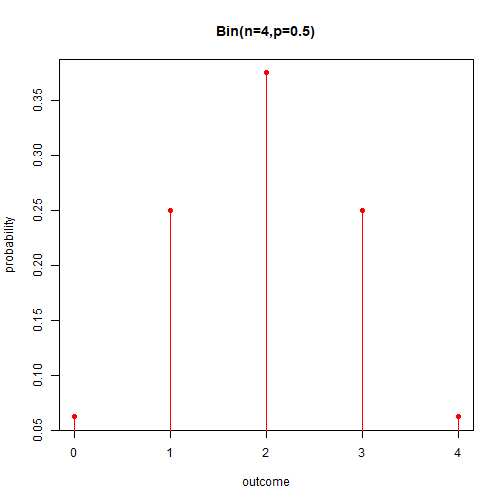

# Binomial distribution

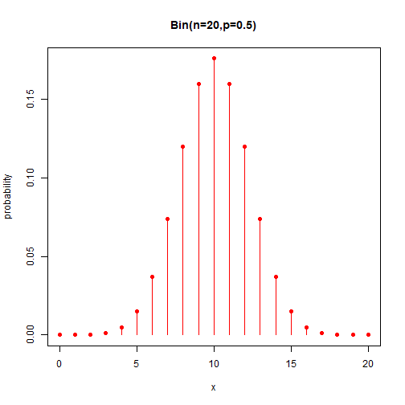

# Binomial distribution

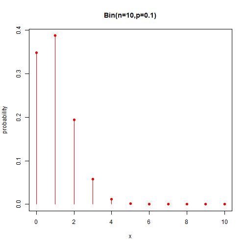

# Binomial distribution

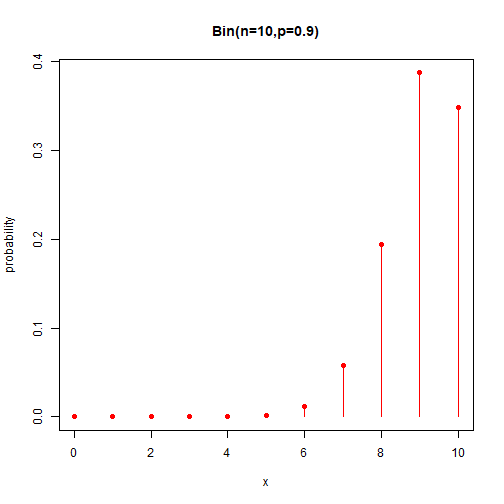

# Exercise

In a population, the probability that the a boy is born is $p = 0.51$. Consider a family of 4 children.

- Find tha probability of having exactly one boy or exactly one girl.
- What is the probability of having at least two boys?.
- Consider another family. What is the number of childresn that a family should have such that the probability of having at least a girl is 0.75?

# Geometric distribution for events

- **Experiment**: Suppose performing Bernoulli trials until we observe **the first time** the outcome A appears.
- **Random variable**: We would like to count the number of $B$’s we obtained
- **Example**: when tossing a coin until observing a tail
- **Question**: What is the probability of tossing the coin $k$ times until the first tail appears?

# Geometric distribution for events

- when transmitting bits and counting the number of bits transmitted **until we find the first error** if the transmission of a single error is $p$:

What is the probability of sending $k$ correct bits until the first error appears?

- when asking people whether they will vote for the political party in government, if the probability that someone votes for the ruling party is $p$:

What is the probability asking $k$ times **until finding the first person** likely to vote for the ruling party?

# Geometric distribution for events

Let’s compute the probability of transmitting bits with $y$ number of bits correctly transmitted ($B$) and the last bit being an error ($A$); when the probability of an error is $p$.

$(0,0,0,..0,1)=(B_1, B_2, B_3, B_y,A_y+1)$

The probability of $y$ events of type $B$ is

$P(0,0,0,..0,1)=P(Y=y)=f(y)=(1-p)^{y}p$

(there is only one possible transmission for $y$ number of correctly trasmitted bits)

# Geometric distribution for events

The geometric distribution for the number of events $B$ before an event $A$ occurs is

$P(Y=y)=f(y)=(1-p)^{y}p$, for $y=0,1,2,...$

and has

- mean: $E(Y)= \sum_{y=0}^\infty y(1-p)^{y}p=\frac{1-p}{p}$
- variance: $V(Y)= \frac{1-p}{p^2}$

# Geometric distribution for events

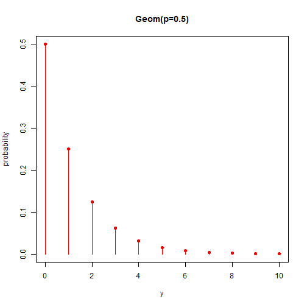

# Geometric distribution for events

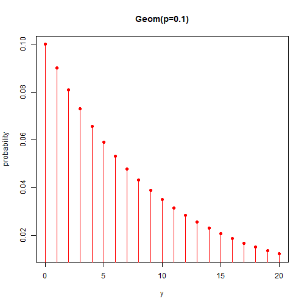

# Geometric distribution for events

Now, consider imagine that we would like to count the number of **trials** using the random varible $M$

$(0,0,0,..0,1)=(B_1, B_2, B_3, B_y,A_y+1)$

The probability of observing $m=y+1$ trials is the same probability of observing $y$ correctly transmitted bits. We only need to change the variable

$P(0,0,0,..0,1)=P(Y=y)=(1-p)^{y}p=(1-p)^{m-1}p=P(M=m)$

Geometric distribution for trials es:

$f(m)=(1-p)^{m-1}p,$, for $m=1,2,3,...$

with

- mean: $E(M)= \sum_{m=1}^\infty m(1-p)^{m-1}p=\frac{1}{p}$
- variance: $V(M)= \frac{1-p}{p^2}$

Note that $y$ starts with 0, while $m$ starts with $1$.

# Negative binomial distribution for events

Now let us imagine that we can be tolerant of a given number of errors in the signal transmission of bits. Say we can tolerate $r$ errors in a transmission.

- Experiment: Suppose performing Bernoulli trials until we observe the outcome $A$ appears $r$ times.
- Random variable: We count the number of events $B$
- Example: What is the probability of observing $k$ well-transmitted ($B$) bits before $r$ errors ($A$)?

# Negative binomial distribution for events

Let’s find first the probability of one particular transmission with $y$ correct bits ($B$) and $r$ errors ($A$).

$(0,0,1,., 0,1,...0,1)=(B_1, B_2, A_3, ..., B_i,A_{i+1}, ... B_{y+r-1},A_{y+r})$

We observe $y$ correct bits ins a total of $y + r$ trials.

Then

- $P(0,0,1,., 0,1,...0,1)=(1-p)^yp^r$
- the last bit is fixed (marks the end of transmission)
- The total number of transmisions with $y$ number of correct bits ($B$) that we can obtain in $y + r-1$ trials is: $\binom {y + r-1} y$

# Negative binomial distribution for events

Therefore, the probability of observing $y$ events of type $B$ before $r$ events of type $A$ (with probability $p$) is

$P(Y=y)=f(y)=\binom {y+r-1} y (1-p)^yp^r$, para $y=0,1,...$

When the distribution of $Y$ is a negative binomial we write

$Y\hookrightarrow NB(r,p)$

# Negative binomial distribution for events

A random variable with $Y\hookrightarrow NB(r,p)$ has

- mean: $E(Y)= r\frac{1-p}{p}$
- variance: $V(Y)= r\frac{1-p}{p^2}$

Note that this is $r$-times those of the geometric distribution.

If we perform $r$-geometric experiments (composed on Bernoulli trials) the expectation for the sum the total amount $B$ events is the same performing a single negative binomial experiment with tolerance $r$.

# Negative binomial distribution for events

- A website has three servers.
- One server operates at a time and only when a request fails another server is used.
- If the probability of failure for a request is known to be $p=0.0005$ then
- what is the expected number of successful requests before the three computers fail?

# Negative binomial distribution for events

This is a negative binomial process for the number of successes $y$ $(y=0,1,2,...)$ before $r=3$ and $p=0.0005$ therefore

$E(Y)=r\frac{1-p}{p}=3\frac{1-0.0005}{0.0005}=5997$

- Note that there are actually 6000 trials

# Negative binomial distribution for events

What is the probability of dealing with at most with 5 successful requests before the system fails?

Recall the cumulative function distribution $F(y)=P(Y\leq 5)$

$F(5)=P(Y\leq 5)=\Sigma_{y=0}^5 f(y)$

$=\sum_{y=0}^5\binom {y+2} y (0.9995)^y(0.0005)^y$

$=\binom {2} 0 (0.0005)^3 +\binom {3} 1 (0.9995)^1*(0.0005)^3$

$+\binom {4} 2 (0.9995)^2*(0.0005)^3 +\binom {5} 3 (0.9995)^3*(0.0005)^3$

$+\binom {6} 4 (0.9995)^4*(0.0005)^3 +\binom {7} 5 (0.9995)^5*(0.0005)^3$

$= 6.9\times 10^{-9}$

# Negative binomial distribution for events

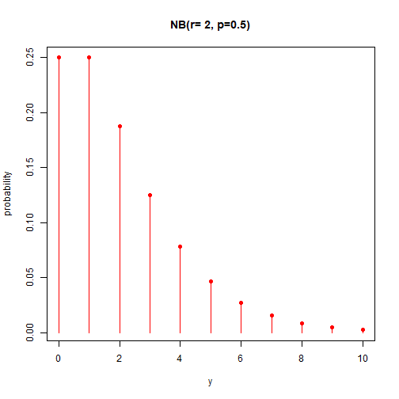

# Negative binomial distribution for events

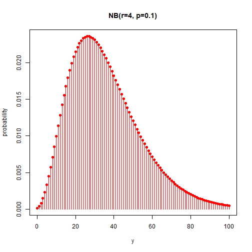

# Negative binomial distribution for trials

If we are interested in counting the number of **trials** before observing $r$ events of type $A$

$(0,0,1,., 0,1,...0,1)=(B_1, B_2, A_3, ..., B_i,A_{i+1}, ... B_{y+r-1},A_{y+r})$

we then count $m=y+r$ trials, and the probability function for $m$ **trials** before $r$ evetns of type $A$ is

$P(M=m)=f(m)=\binom {m-1} {r-1} (1-p)^{m-r}p^r$, $m=r,r+1,...$

with

- mean: $E(M)= \frac{r}{p}$
- variance: $V(M)= \frac{r(1-p)}{p^2}$

# Hypergeometric distribution

- Imagine we have a manufacturing process that for every $850$ devices it produces per hour, $50$ tend to be defective ($5\%$).
- We don’t have time to count them all so we select $100$ at random.
- what is the probability that we choose $5$ ($5\%$) defective devices?

# Hypergeometric distribution

What do we know?

- From a population of $N$
- There are $K$ that are not good ($N-K$ are good)
- A sample of $n$ is chosen
- In the sample, there are $x$ taht are not good

what is the probability of observing a given value $x$?

# Hypergeometric distribution

What do we know

- From a population of $N$
- There are $K$ that are not good ($N-K$ are good)

Let’s imagine we can mark each good devise $B_1, ... B_K$ and each defective one $A_1, ... A_ {N_K}$.

The population of devices is $\{B_1, ... B_K, A_1, ... A_ {N_K} \}$

# Hypergeometric distribution

From the population $\{B_1, ... B_ {N-K}, A_1, ... A_ {K} \}$ we choose a sample of size $n$.

- there are $\binom N n$ of these samples
- our particular sample

$(A_1, B_2, ... A_i,..B_{n})$

has probability

$P(A_1, B_2, ... A_i,..B_{n})=\frac{1}{\binom N n}$

let’s assume that our sample has $x$ bad devices ($A$)

¿How many samples can we obtain with the same number $x$ of bad devices?

# Hypergeometric distribution

- In how many ways we could get $x$ different bad devises from a pool of $K$?

$$\binom K x$$

- In how many ways we could get $n-x$ different good devices from a pool of $N-K$?

$$\binom {N-K} {n-x}$$

All these samples have the same number of $A$s that our original sample $(A_1, B_2, ... A_i,..B_{n})$

# Hypergeometric distribution

Therefore the probability of obtaining $x$ bad devises in a sample of $n$ drawn from a population of $N$ where $K$ are bad is

$P(X=k)=P(one\,sample) \times (Number\, of\, ways\, of\, obtaining\, x)$

$=\frac{1}{\binom N n}\binom K x \binom {N-K} {n-x}$

where $k \in \{\max(0, n+K-N), ... \min(K, n) \}$

# Hypergeometric distribution

Let’s think about the range of $x$

$k \in \{\max(0, n+x-N), ... \min(K, n) \}$

if there are few good devices and all get selected then there are at least $n-(N-K)$ bad ones.

# Hypergeometric distribution

- Imagine we have a manufacturing process that for every 850 devices it produces per hour 50 tend to be defective ($5\%$).
- We don’t have time to count them all so we select 100 at random.
- what is the probability that we choose 5 defective devices?

# Hypergeometric distribution

- From a population of $N=850$
- There are $K=50$ that are not good ($N-K=800$ are good)
- A sample of $n=100$ is chosen

The probability that in the sample there are $k=5$ devices that are not good:

$P(X=k) =\frac{1}{\binom N n}\binom K k \binom {N-K} {n-k}$

$P(X=5) =\frac{1}{\binom {850} {100}}\binom {50} {5} \binom {800} {95} = 0.17\,\, (17\%)$

in R: `choose(50, 5)*choose(800, 95)/choose(850, 100)`

# Hypergeometric distribution

Note that:

- there are $5.8\%$ of bad devices in the population ($850$)
- $5$ bad devises in the sample ($100$) represent the $5\%$

# Hypergeometric distribution

These are not Bernoulli trials.

- Independent Bernoulli trials will result if we inspect one device, drop it back, and take a new one (it can be the same).
- In this case, we have sampling **without replacement**
- At each draw of a device the sampling population change!

# Hypergeometric distribution

If a random variable follows a hypergeometric mass probability function

$P(X=x)=f(x)=\frac{1}{\binom N n}\binom K x \binom {N-K} {n-x}$

$x \in \{\max(0, n+K-N), ... \min(K, n) \}$

It has

- mean: $E (X) = n * K / N = np$
- variance: $V (X) = np (1-p) \frac {N-n} {N-1}}$

when $p=K/N$ is the proportion of events $A$ in a population of size $N$.

# Hypergeometric distribution

Let’s compare the means and variances from a **binomial** variable

- $E_B(X)=np$ and variance $V_B(X)= np(1-p)$

and a **Hypergeometric** variable

- $E(X)=np$ and variance $V(X)= np(1-p)\frac{N-n}{N-1}$

The variance of the hypergeometric distribution is corrected for the sampling without replacement in a population with finite size.

The binomial distribution is derived from a sampling with **replacement**

The hipergoemetric distribution is derived from a sampling with **no replacement**, its variance is corrected from the efect of sampling a population with **finite** size.

# Hypergeometric distribution

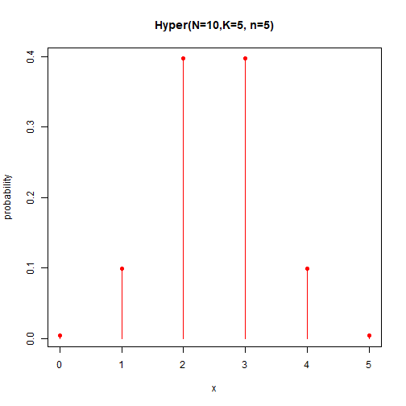

# Hypergeometric distribution

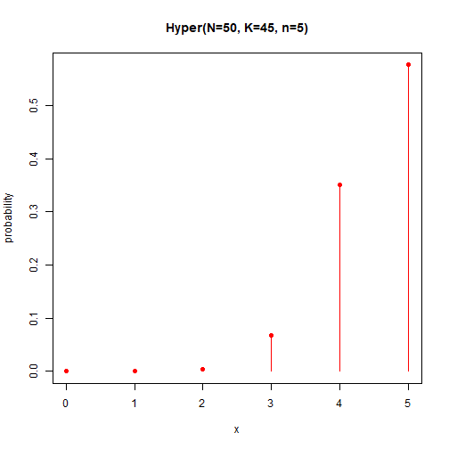

# Discrete probability models

We are building up more complex models from simple ones:

**Uniform**: Classical interpretation of probability  
$\downarrow$  
**Bernoulli**: Introduction of a **parameter** $p$ (family of functions)  
$\downarrow$  
**Binomial**: **Repetition** of a random experiment ($n$-times Bernoulli trials)  
$\downarrow$  
**Poisson**: repetition of random experiment within an continuous interval (having **no control** on when/where to repeat the experiment).

# Poisson distribution

Imagine that we are observing events that **depend** on time or distance **intervals**.

- cars arriving at a traffic light
- getting messages on your mobile phone
- flaws occurring at random in a copper wire

Suppose that the events are outcomes of **independent** random experiments each appearing randomly on a continuous interval.

# Poisson distribution

- When we studied the binomial process we thought of repeating the flip of a coin $n$ times.
- We implicitly assumed that we **controlled** when the repetitions occurred.
- Now we consider another layer of randomness: we do not control when the flip of the coin happens!

# Poisson distribution

What is the probability of observing $X$ events in an interval’s unit (time or distance)?

Imagine that some impurities in a copper wire deposit randomly along a wire

- at each centimeter, you would count an average of $\lambda=10/cm$.
- divide the centimeter into micrometers ($0.0001cm$)

# Poisson distribution

micrometers are small enough so

- either there is or there is not an impurity in each micrometer
- each micrometer can be considered a **Bernoulli trial**

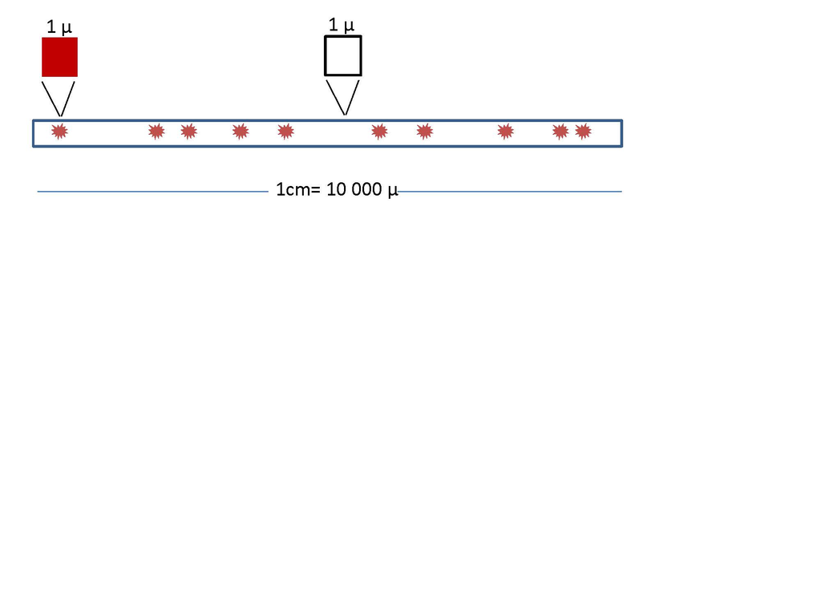

# Poisson distribution

The probability of observing $X$ impurities in $n=10,000\mu$ (1cm) approximately follows a binomial distribution

$P(X=x)=\binom n x (1-p)^{n-x}p^x$

where $p$ is the probability of finding an impurity in a micrometer.

Remember that $E(X)=np$ so for $\lambda=np$ (average number of impurities per 1cm), we can write

$P(X=x)=\binom n x (1-\frac{\lambda}{n})^{n-x}\big(\frac{\lambda}{n}\big)^x$

# Poisson distribution

- There **could** still be two flaws in a micrometer so we need to increase the partition of the wire ($n$).
- The Bernoulli trials are only true in the limit ($n \rightarrow \infty$).

$P(X=x)=\binom n x (1-\frac{\lambda}{n})^{n-x}\big(\frac{\lambda}{n}\big)^x$

Where $\lambda$ is constant because it is the density of flaws per centimeter, given by $E(X)$.

# Poisson distribution

$P(X=x)=\binom n x (1-\frac{\lambda}{n})^{n-x} \big(\frac{\lambda}{n}\big)^x$

in the limit ($n \rightarrow \infty$)

- $\frac{1}{n^x}\binom n x =\frac{1}{n^x}\frac{n!}{x! (n-x)!}=\frac{(n-x)!(n-x+1)...(n-1)n}{n^x x! (n-x)!}=\frac{n(n-1)..(n-x+1)}{n^x x!} \rightarrow \frac{1}{x!}$
- $(1-\frac{\lambda}{n})^{n} \rightarrow e^{-\lambda}$ (definition of exponential)
- $(1-\frac{\lambda}{n})^{-x} \rightarrow 1$

Therefore $P(X=x)= \frac{e^{-\lambda}\lambda^x}{x!}$

# Poisson distribution

**Definition**

Given

- an interval in the real numbers
- counts occur at random in the interval
- the average number of counts on the interval is known ($\lambda$)
- if one can find a small regular partition of the interval such that each of them can be considered Bernoulli trials

Then…

# Poisson distribution

**Definition**

The random experiment of counting across the interval is a **Poisson** process and the counts $X$ follow the probability mass function  
$f(x)= \frac{e^{-\lambda}\lambda^x}{x!}, \lambda>0$

# Poisson distribution

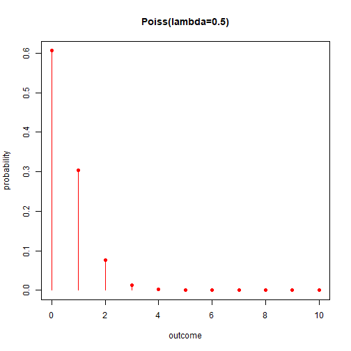

# Poisson distribution

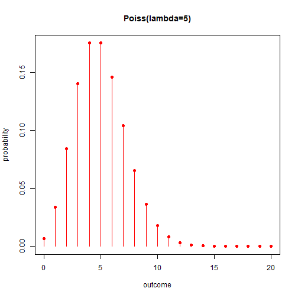

# Poisson distribution

for the Poisson distribution  
$f(x)=\frac{e^{-\lambda}\lambda^x}{x!}, \lambda>0$

we have

- mean $E(X)= \lambda$
- variance $V(X)= \lambda$

# Poisson distribution

The average number of radioactive particles hitting a Geiger counter is 2.3 seconds.

What is the probability of counting exactly 2 particles in a second?

$f(x; \lambda)=\frac{e^{-\lambda}\lambda^x}{x!}, \lambda>0$

$f(2; \lambda=2.3)=\frac{e^{-2.3}2.3^2}{2!}=0.26, \lambda=2.3\, counts$

# Poisson distribution

The average number of radioactive particles hitting a Geiger counter is 2.3 counts each second.

What is the probability of counting exactly detecting 10 particles in 5 seconds?

If the probabilit of counts per 1 second is

$f(x; \lambda_{1s})=\frac{e^{-\lambda_{1s}}\lambda_{1s}^x}{x!}, \lambda_{1s}=2.3\, counts$

y $E(X)=\lambda_{1s}$

Then the avereage coutns per 5 seconds is

$E(Y)=5\times \lambda_{1s}=\lambda_{5s}$ (we have to wait 5 units of times more)

The probability function fo $Y$ is

$f(y; \lambda_{5s})=\frac{e^{-\lambda_{5s}}\lambda_{5s}^y}{y!}, \lambda_{5s}=11.5 \, counts$

therefore

$f(10; \lambda_{5s})=\frac{e^{-11.5}11.5^{10}}{{10!}}=0.11, \lambda_{5s}=11.5 \,counts$

# Poisson distribution

What is the probability of at least one count in two seconds?

In general, the average of counts per $\alpha$ seconds is

$E(Z; \lambda_{\alpha})=\lambda = \alpha \times \lambda_{\alpha}$

when $\alpha=2$

$E(Z; \lambda_{2s})=\lambda_{2s} = 2 \lambda_{1s} =4.6 \, conteos$

# Summary

[output not shown]